# BacLe Project5 Computer Vision Plant Seedlings Classification

## Problem Statement

### Context

In recent times, the field of agriculture has been in urgent need of modernizing, since the amount of manual work people need to put in to check if plants are growing correctly is still highly extensive. Despite several advances in agricultural technology, people working in the agricultural industry still need to have the ability to sort and recognize different plants and weeds, which takes a lot of time and effort in the long term. The potential is ripe for this trillion-dollar industry to be greatly impacted by technological innovations that cut down on the requirement for manual labor, and this is where Artificial Intelligence can actually benefit the workers in this field, as **the time and energy required to identify plant seedlings will be greatly shortened by the use of AI and Deep Learning.** The ability to do so far more efficiently and even more effectively than experienced manual labor, could lead to better crop yields, the freeing up of human inolvement for higher-order agricultural decision making, and in the long term will result in more sustainable environmental practices in agriculture as well.

### Objective

The aim of this project is to Build a Convolutional Neural Netowrk to classify plant seedlings into their respective categories.

### Data Dictionary

The Aarhus University Signal Processing group, in collaboration with the University of Southern Denmark, has recently released a dataset containing **images of unique plants belonging to 12 different species.**

- The dataset can be download from Olympus.
- The data file names are:
  - images.npy
  - Labels.csv
- Due to the large volume of data, the images were converted to the images.npy file and the labels are also put into Labels.csv, so that you can work on the data/project seamlessly without having to worry about the high data volume.
- The goal of the project is to create a classifier capable of determining a plant's species from an image.

**List of Species**

- Black-grass
- Charlock
- Cleavers
- Common Chickweed
- Common Wheat
- Fat Hen
- Loose Silky-bent
- Maize
- Scentless Mayweed
- Shepherds Purse
- Small-flowered Cranesbill
- Sugar beet

### **Note: Please use GPU runtime on Google Colab to execute the code faster.**

## Importing necessary libraries

```python
!pip install tensorflow==2.17.0 scikit-learn seaborn==0.13.1 matplotlib numpy pandas \
             opencv-python opencv-contrib-python -q --user
```

```python
import numpy as np
import pandas as pd
import seaborn as sns
import matplotlib.pyplot as plt
import math, random

import cv2
import PIL
from PIL import Image

# Keras Sequential Model
import tensorflow
import tensorflow as tf
from tensorflow import keras
from tensorflow.keras.models import Sequential

# Importing all the different layers and optimizers
from tensorflow.keras.layers import (
    Dense, Dropout, Flatten, Conv2D, MaxPooling2D, BatchNormalization, Activation, LeakyReLU
)
from tensorflow.keras.optimizers import Adam,SGD
from tensorflow.keras import backend
from tensorflow.keras.callbacks import EarlyStopping

from tensorflow.keras.preprocessing.image import ImageDataGenerator

import keras_tuner as kt
from keras_tuner import RandomSearch
from kerastuner.engine.hyperparameters import HyperParameters
from keras.preprocessing.image import load_img, save_img, img_to_array, array_to_img
from keras.applications.vgg16 import VGG16

from sklearn import metrics
from sklearn.metrics import (
    f1_score,
    accuracy_score,
    recall_score,
    precision_score,
    confusion_matrix,
    classification_report,
)
from sklearn.model_selection import (
    train_test_split,
)
from sklearn.preprocessing import StandardScaler, OneHotEncoder, LabelBinarizer, LabelEncoder


# The below code can be used to ignore the warnings that may occur due to deprecations
import warnings
warnings.filterwarnings("ignore")
tf.config.run_functions_eagerly(True)
```

```
C:\Users\Mark Le\AppData\Local\Temp\ipykernel_5084\314669194.py:27: DeprecationWarning: `import kerastuner` is deprecated, please use `import keras_tuner`.
  from kerastuner.engine.hyperparameters import HyperParameters
```

## Loading the dataset

```python
# Loading BRG images for numpy array file
image = np.load('images.npy')
```

```python
# loading the target labels
label = pd.read_csv('Labels.csv')
```

```python
# Separate target variable
y_label = label['Label']
```

## Data Overview

### Understand the shape of the dataset

```python
# There are 4750 color images size 128x128 with 3 channels (RGB)
image.shape
```

```
(4750, 128, 128, 3)
```

```python
# Display first 5 target labels
y_label.head()
```

```
0    Small-flowered Cranesbill
1    Small-flowered Cranesbill
2    Small-flowered Cranesbill
3    Small-flowered Cranesbill
4    Small-flowered Cranesbill
Name: Label, dtype: object
```

```python
# Confirming its shape
y_label.shape
```

```
(4750,)
```

```python
# Create a list of 12 classes
cat_labels=np.unique(y_label)
cat_labels
```

```
array(['Black-grass', 'Charlock', 'Cleavers', 'Common Chickweed',
       'Common wheat', 'Fat Hen', 'Loose Silky-bent', 'Maize',
       'Scentless Mayweed', 'Shepherds Purse',
       'Small-flowered Cranesbill', 'Sugar beet'], dtype=object)
```

### Data Visualization

```python
# function to display images
def display_images(data, target):
    num_classes=target.nunique()                                                    # Number of Classes
                                                                                    # Obtaing the unique classes from label
    rows = cols = 4                                                                 # Defining number of rows=4 and cols=4
    fig = plt.figure(figsize=(10, 8))                                               # Defining the figure size to 10x8
    for i in range(rows):
        for j in range(cols):
            random_index = np.random.randint(0, len(target))                         # Generating random indices from the data and plotting the images
            ax = fig.add_subplot(rows, cols, i * rows + j + 1)                       # Adding subplots with 4 rows and 4 columns
            ax.imshow(data[random_index, :], cmap=plt.get_cmap('gray'))              # Plotting the image using cmap=gray
            ax.set_title(target[random_index])                                       # Plotting the title
            plt.subplots_adjust(wspace=0.3, hspace=0.5)                              # Adding some spaces between images
    plt.show()
```

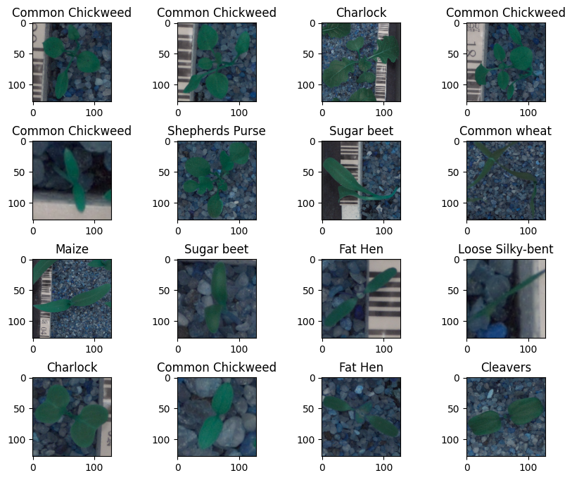

```python
# Display BGR images
display_images(image, y_label)
```

- The images of the young seedlings are in BGR format with top-down view.
- Some images contain small pebbles and a ruler for measurement.

## Exploratory Data Analysis

- EDA is an important part of any project involving data.
- It is important to investigate and understand the data better before building a model with it.
- A few questions have been mentioned below which will help you understand the data better.
- A thorough analysis of the data, in addition to the questions mentioned below, should be done.
1. How are these different category plant images different from each other?
2. Is the dataset provided an imbalance? (Check with using bar plots)

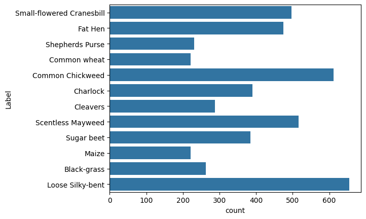

```python
# Plot distribution of each category
count_plot = sns.countplot(y_label)
```

- The images of the young seedlings are similar in green color. Only the leaf texture and the shape of the stem are different from each other.
- The background of the images is somewhat uniform. The growth stages of the plant seedlings make the distinction more difficult for our eyes to see.
- The dataset is imbalanced. The categories of Shepherds Purse, Common Wheat, and Maize have the least observations.
- Loose Silky-bent category has the most representation.

## Data Pre-Processing

### Convert the BGR images to RGB images.

```python
# 1st option: conversion with cv2
for i in range(len(image)):
   image[i] = cv2.cvtColor(image[i], cv2.COLOR_BGR2RGB)
```

```python
# 2nd option: reversing B & R channels
# image = image[:,:,:,::-1]
```

### Resize the images

As the size of the images is large, it may be computationally expensive to train on these larger images; therefore, it is preferable to reduce the image size from 128 to 64.

```python
# Create a list of resized images
resized_list = []
height = 64
width = 64
dimensions = (width, height)
for i in range(len(image)):
  resized_list.append(cv2.resize(image[i], dimensions, interpolation=cv2.INTER_LINEAR))
```

```python
# Convert list to numpy array
resized_image = np.array(resized_list)
resized_image.shape
```

```
(4750, 64, 64, 3)
```

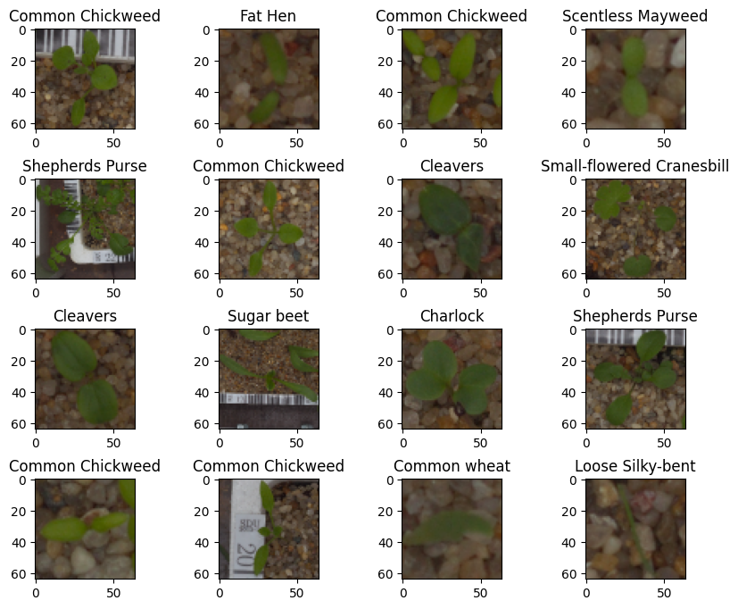

```python
# Display RGB images
display_images(resized_image, y_label)
```

### Data Preparation for Modeling

- Before you proceed to build a model, you need to split the data into train, test, and validation to be able to evaluate the model that you build on the train data
- You'll have to encode categorical features and scale the pixel values.
- You will build a model using the train data and then check its performance

#### Split the dataset

```python
X = resized_image
y = y_label
```

```python
# Splitting the dataset into the Training, Validation, and Test set.
X_train, X_test, y_train, y_test = train_test_split(X, y, test_size=0.2, random_state=42, stratify=y)
X_train, X_val, y_train, y_val = train_test_split(X_train, y_train, test_size=0.2, random_state=42, stratify=y_train)
```

```python
# Display shapes
print(X_train.shape, y_train.shape)
print(X_val.shape, y_val.shape)
print(X_test.shape, y_test.shape)
```

```
(3040, 64, 64, 3) (3040,)
(760, 64, 64, 3) (760,)
(950, 64, 64, 3) (950,)
```

#### Encode the target labels

```python
# Encoding the target variable to numbers 1 to 12 as the target index.  Note: sparse_categorical_crossentropy.
encoder = LabelEncoder()
y_train = encoder.fit_transform(y_train)
y_val = encoder.transform(y_val)
y_test = encoder.transform(y_test)
```

```python
# Display shapes of target variables
print(y_train.shape)
print(y_val.shape)
print(y_test.shape)
```

```
(3040,)
(760,)
(950,)
```

#### Data Normalization

```python
# Min & Max values of the independent variable
print(X_train.max(), X_val.max(), X_test.max())
print(X_train.min(), X_val.min(), X_test.min())
```

```
255 255 255
0 0 0
```

```python
X_train, X_val, X_test = X_train.astype('float32')/(255), X_val.astype('float32')/(255), X_test.astype('float32')/(255)
```

```python
# Min & Max values of the independent variable after scaling
print(X_train.max(), X_val.max(), X_test.max())
print(X_train.min(), X_val.min(), X_test.min())
```

```
1.0 1.0 1.0
0.0 0.0 0.0
```

## Model Building

```python
# function to plot the loss and accuracy values
def plot(history, name):
    """
    Function to plot loss/accuracy

    history: an object which stores the metrics and losses.
    name: can be one of Loss or Accuracy
    """
    fig, ax = plt.subplots() #Creating a subplot with figure and axes.
    plt.plot(history.history[name]) #Plotting the train accuracy or train loss
    plt.plot(history.history['val_'+name]) #Plotting the validation accuracy or validation loss

    plt.title('Model ' + name.capitalize()) #Defining the title of the plot.
    plt.ylabel(name.capitalize()) #Capitalizing the first letter.
    plt.xlabel('Epoch') #Defining the label for the x-axis.
    fig.legend(['Train', 'Validation'], loc="outside right upper") #Defining the legend, loc controls the position of the legend.
```

```python
# defining a function to compute different metrics to check performance of a classification model built using sklearn
def model_performance_classification_sklearn(model, predictors, target):
    '''
    Function to compute different metrics to check classification model performance

    model: classifier
    predictors: independent variables
    target: dependent variable
    '''

    # predicting using the independent variables
    pred = model.predict(predictors)

    acc = accuracy_score(target, pred)  # to compute Accuracy
    recall = recall_score(target, pred)  # to compute Recall
    precision = precision_score(target, pred)  # to compute Precision
    f1 = f1_score(target, pred)  # to compute F1-score

    # creating a dataframe of metrics
    df_perf = pd.DataFrame(
        {
            'Accuracy': acc,
            'Recall': recall,
            'Precision': precision,
            'F1': f1

        },
        index=[0],
    )

    return df_perf
```

```python
# function to display confusion matrix
def confusion_matrix_tf(target, prediction):

    cm = tf.math.confusion_matrix(target, prediction).numpy()

    f, ax = plt.subplots(figsize=(10,8))
    sns.heatmap(cm, annot=True, linewidths=0.4, fmt='', square=True, ax=ax)
    ticks = np.arange(len(cat_labels))
    plt.xticks(ticks, cat_labels, rotation=90)
    plt.yticks(ticks, cat_labels, rotation=0)

    for label in ax.get_xticklabels():
        label.set_horizontalalignment('left')
    for label in ax.get_yticklabels():
        label.set_verticalalignment('top')

    plt.xlabel('Predicted label')
    plt.ylabel('True label')
    plt.tight_layout()
    plt.show
```

```python
# clears the current Keras session & seed
def reset_session():
    tf.keras.backend.clear_session()
    np.random.seed(42)
    random.seed(42)
    tf.random.set_seed(42)
```

```python
# function for custom callbacks
def scheduler(epoch, lr):
     if epoch < 10:
         return lr
     else:
         return lr * math.exp(-0.1)
```

#### Initialization

```python
# For simplicity, this input shape is used for several models.
input_shape = (64, 64, 3)
```

```python
# Creating callbacks API
early_stopping = EarlyStopping(monitor='val_loss', patience=20, restore_best_weights=True)
reduce_lr = tf.keras.callbacks.ReduceLROnPlateau(monitor='val_loss', factor=0.2, patience=10, min_lr=0.001)
lr_scheduler = keras.callbacks.LearningRateScheduler(scheduler)
```

#### 1st Model

```python
# function to return Keras model
def create_model():

    model = Sequential()

    model.add(Conv2D(64, (3,3), activation='relu', padding='same', input_shape=input_shape))
    model.add(MaxPooling2D((2,2), padding='same'))

    model.add(Conv2D(32, (3,3), activation='relu', padding='same'))
    model.add(MaxPooling2D((2,2), padding='same'))

    model.add(Conv2D(32, (3,3), activation='relu', padding='same'))
    model.add(MaxPooling2D((2,2), padding='same'))

    model.add(Flatten())

    model.add(Dense(128, activation='relu'))
    model.add(BatchNormalization())

    model.add(Dense(12, activation='softmax'))

    opt=SGD(learning_rate=1e-3, momentum=0.9)
    model.compile(loss='sparse_categorical_crossentropy', optimizer=opt, metrics=['accuracy'])

    return model
```

```python
model = create_model()
```

```python
model.summary()
```

```
Model: "sequential_4"
```

```
┏━━━━━━━━━━━━━━━━━━━━━━━━━━━━━━━━━┳━━━━━━━━━━━━━━━━━━━━━━━━┳━━━━━━━━━━━━━━━┓
┃ Layer (type)                    ┃ Output Shape           ┃       Param # ┃
┡━━━━━━━━━━━━━━━━━━━━━━━━━━━━━━━━━╇━━━━━━━━━━━━━━━━━━━━━━━━╇━━━━━━━━━━━━━━━┩
│ conv2d_16 (Conv2D)              │ (None, 64, 64, 64)     │         1,792 │
├─────────────────────────────────┼────────────────────────┼───────────────┤
│ max_pooling2d_8 (MaxPooling2D)  │ (None, 32, 32, 64)     │             0 │
├─────────────────────────────────┼────────────────────────┼───────────────┤
│ conv2d_17 (Conv2D)              │ (None, 32, 32, 32)     │        18,464 │
├─────────────────────────────────┼────────────────────────┼───────────────┤
│ max_pooling2d_9 (MaxPooling2D)  │ (None, 16, 16, 32)     │             0 │
├─────────────────────────────────┼────────────────────────┼───────────────┤
│ conv2d_18 (Conv2D)              │ (None, 16, 16, 32)     │         9,248 │
├─────────────────────────────────┼────────────────────────┼───────────────┤
│ max_pooling2d_10 (MaxPooling2D) │ (None, 8, 8, 32)       │             0 │
├─────────────────────────────────┼────────────────────────┼───────────────┤
│ flatten_4 (Flatten)             │ (None, 2048)           │             0 │
├─────────────────────────────────┼────────────────────────┼───────────────┤
│ dense_10 (Dense)                │ (None, 128)            │       262,272 │
├─────────────────────────────────┼────────────────────────┼───────────────┤
│ batch_normalization_18          │ (None, 128)            │           512 │
│ (BatchNormalization)            │                        │               │
├─────────────────────────────────┼────────────────────────┼───────────────┤
│ dense_11 (Dense)                │ (None, 12)             │         1,548 │
└─────────────────────────────────┴────────────────────────┴───────────────┘
```

```
 Total params: 293,836 (1.12 MB)
```

```
 Trainable params: 293,580 (1.12 MB)
```

```
 Non-trainable params: 256 (1.00 KB)
```

```python
history = model.fit(X_train, y_train, epochs=75, validation_data=(X_val, y_val), shuffle=True, batch_size=64, verbose=1, callbacks=[early_stopping, lr_scheduler])
```

```
48/48 ━━━━━━━━━━━━━━━━━━━━ 8s 171ms/step - accuracy: 0.1178 - loss: 2.4916 - val_accuracy: 0.1987 - val_loss: 2.4650 - learning_rate: 0.0010
48/48 ━━━━━━━━━━━━━━━━━━━━ 8s 167ms/step - accuracy: 0.3005 - loss: 2.1214 - val_accuracy: 0.3171 - val_loss: 2.3964 - learning_rate: 0.0010
48/48 ━━━━━━━━━━━━━━━━━━━━ 8s 174ms/step - accuracy: 0.4204 - loss: 1.7249 - val_accuracy: 0.3000 - val_loss: 2.2877 - learning_rate: 0.0010
48/48 ━━━━━━━━━━━━━━━━━━━━ 8s 162ms/step - accuracy: 0.4855 - loss: 1.5325 - val_accuracy: 0.3329 - val_loss: 2.1805 - learning_rate: 0.0010
48/48 ━━━━━━━━━━━━━━━━━━━━ 8s 164ms/step - accuracy: 0.5384 - loss: 1.3828 - val_accuracy: 0.3803 - val_loss: 2.0402 - learning_rate: 0.0010
48/48 ━━━━━━━━━━━━━━━━━━━━ 8s 161ms/step - accuracy: 0.5856 - loss: 1.2644 - val_accuracy: 0.3513 - val_loss: 1.9297 - learning_rate: 0.0010
48/48 ━━━━━━━━━━━━━━━━━━━━ 8s 175ms/step - accuracy: 0.6270 - loss: 1.1837 - val_accuracy: 0.3487 - val_loss: 1.7921 - learning_rate: 0.0010
48/48 ━━━━━━━━━━━━━━━━━━━━ 8s 164ms/step - accuracy: 0.6659 - loss: 1.0846 - val_accuracy: 0.4184 - val_loss: 1.6600 - learning_rate: 0.0010
48/48 ━━━━━━━━━━━━━━━━━━━━ 8s 170ms/step - accuracy: 0.6990 - loss: 1.0103 - val_accuracy: 0.4184 - val_loss: 1.5508 - learning_rate: 0.0010
48/48 ━━━━━━━━━━━━━━━━━━━━ 8s 171ms/step - accuracy: 0.7316 - loss: 0.9367 - val_accuracy: 0.4461 - val_loss: 1.4418 - learning_rate: 0.0010
48/48 ━━━━━━━━━━━━━━━━━━━━ 8s 168ms/step - accuracy: 0.7535 - loss: 0.8797 - val_accuracy: 0.5132 - val_loss: 1.3498 - learning_rate: 9.0484e-04
48/48 ━━━━━━━━━━━━━━━━━━━━ 8s 169ms/step - accuracy: 0.7644 - loss: 0.8270 - val_accuracy: 0.5697 - val_loss: 1.2414 - learning_rate: 8.1873e-04
48/48 ━━━━━━━━━━━━━━━━━━━━ 8s 167ms/step - accuracy: 0.7796 - loss: 0.7832 - val_accuracy: 0.5724 - val_loss: 1.1647 - learning_rate: 7.4082e-04
48/48 ━━━━━━━━━━━━━━━━━━━━ 8s 167ms/step - accuracy: 0.7876 - loss: 0.7464 - val_accuracy: 0.6316 - val_loss: 1.0725 - learning_rate: 6.7032e-04
48/48 ━━━━━━━━━━━━━━━━━━━━ 8s 169ms/step - accuracy: 0.8020 - loss: 0.7165 - val_accuracy: 0.6329 - val_loss: 1.0442 - learning_rate: 6.0653e-04
48/48 ━━━━━━━━━━━━━━━━━━━━ 8s 168ms/step - accuracy: 0.8070 - loss: 0.6931 - val_accuracy: 0.6776 - val_loss: 0.9969 - learning_rate: 5.4881e-04
48/48 ━━━━━━━━━━━━━━━━━━━━ 8s 164ms/step - accuracy: 0.8178 - loss: 0.6751 - val_accuracy: 0.6908 - val_loss: 0.9682 - learning_rate: 4.9659e-04
48/48 ━━━━━━━━━━━━━━━━━━━━ 8s 162ms/step - accuracy: 0.8204 - loss: 0.6473 - val_accuracy: 0.7276 - val_loss: 0.8828 - learning_rate: 4.4933e-04
48/48 ━━━━━━━━━━━━━━━━━━━━ 8s 169ms/step - accuracy: 0.8388 - loss: 0.6212 - val_accuracy: 0.7303 - val_loss: 0.8783 - learning_rate: 4.0657e-04
48/48 ━━━━━━━━━━━━━━━━━━━━ 8s 171ms/step - accuracy: 0.8354 - loss: 0.6038 - val_accuracy: 0.7395 - val_loss: 0.8532 - learning_rate: 3.6788e-04
48/48 ━━━━━━━━━━━━━━━━━━━━ 8s 173ms/step - accuracy: 0.8475 - loss: 0.5857 - val_accuracy: 0.7368 - val_loss: 0.8491 - learning_rate: 3.3287e-04
48/48 ━━━━━━━━━━━━━━━━━━━━ 8s 164ms/step - accuracy: 0.8547 - loss: 0.5714 - val_accuracy: 0.7382 - val_loss: 0.8443 - learning_rate: 3.0119e-04
48/48 ━━━━━━━━━━━━━━━━━━━━ 8s 167ms/step - accuracy: 0.8597 - loss: 0.5607 - val_accuracy: 0.7342 - val_loss: 0.8555 - learning_rate: 2.7253e-04
48/48 ━━━━━━━━━━━━━━━━━━━━ 8s 164ms/step - accuracy: 0.8599 - loss: 0.5515 - val_accuracy: 0.7368 - val_loss: 0.8398 - learning_rate: 2.4660e-04
48/48 ━━━━━━━━━━━━━━━━━━━━ 8s 165ms/step - accuracy: 0.8611 - loss: 0.5427 - val_accuracy: 0.7421 - val_loss: 0.8275 - learning_rate: 2.2313e-04
48/48 ━━━━━━━━━━━━━━━━━━━━ 8s 163ms/step - accuracy: 0.8638 - loss: 0.5348 - val_accuracy: 0.7487 - val_loss: 0.8098 - learning_rate: 2.0190e-04
48/48 ━━━━━━━━━━━━━━━━━━━━ 8s 164ms/step - accuracy: 0.8657 - loss: 0.5268 - val_accuracy: 0.7500 - val_loss: 0.8025 - learning_rate: 1.8268e-04
48/48 ━━━━━━━━━━━━━━━━━━━━ 8s 161ms/step - accuracy: 0.8700 - loss: 0.5198 - val_accuracy: 0.7474 - val_loss: 0.7920 - learning_rate: 1.6530e-04
48/48 ━━━━━━━━━━━━━━━━━━━━ 8s 167ms/step - accuracy: 0.8728 - loss: 0.5138 - val_accuracy: 0.7474 - val_loss: 0.7926 - learning_rate: 1.4957e-04
48/48 ━━━━━━━━━━━━━━━━━━━━ 8s 164ms/step - accuracy: 0.8760 - loss: 0.5084 - val_accuracy: 0.7500 - val_loss: 0.8003 - learning_rate: 1.3534e-04
48/48 ━━━━━━━━━━━━━━━━━━━━ 8s 168ms/step - accuracy: 0.8766 - loss: 0.5040 - val_accuracy: 0.7474 - val_loss: 0.8042 - learning_rate: 1.2246e-04
48/48 ━━━━━━━━━━━━━━━━━━━━ 8s 168ms/step - accuracy: 0.8765 - loss: 0.4998 - val_accuracy: 0.7487 - val_loss: 0.8075 - learning_rate: 1.1080e-04
48/48 ━━━━━━━━━━━━━━━━━━━━ 8s 165ms/step - accuracy: 0.8797 - loss: 0.4963 - val_accuracy: 0.7474 - val_loss: 0.8115 - learning_rate: 1.0026e-04
48/48 ━━━━━━━━━━━━━━━━━━━━ 8s 170ms/step - accuracy: 0.8800 - loss: 0.4932 - val_accuracy: 0.7461 - val_loss: 0.8166 - learning_rate: 9.0718e-05
48/48 ━━━━━━━━━━━━━━━━━━━━ 8s 170ms/step - accuracy: 0.8801 - loss: 0.4904 - val_accuracy: 0.7461 - val_loss: 0.8190 - learning_rate: 8.2085e-05
48/48 ━━━━━━━━━━━━━━━━━━━━ 8s 165ms/step - accuracy: 0.8816 - loss: 0.4881 - val_accuracy: 0.7526 - val_loss: 0.8264 - learning_rate: 7.4274e-05
48/48 ━━━━━━━━━━━━━━━━━━━━ 8s 171ms/step - accuracy: 0.8826 - loss: 0.4862 - val_accuracy: 0.7553 - val_loss: 0.8272 - learning_rate: 6.7206e-05
48/48 ━━━━━━━━━━━━━━━━━━━━ 8s 164ms/step - accuracy: 0.8827 - loss: 0.4847 - val_accuracy: 0.7539 - val_loss: 0.8296 - learning_rate: 6.0810e-05
48/48 ━━━━━━━━━━━━━━━━━━━━ 8s 167ms/step - accuracy: 0.8840 - loss: 0.4834 - val_accuracy: 0.7566 - val_loss: 0.8256 - learning_rate: 5.5023e-05
48/48 ━━━━━━━━━━━━━━━━━━━━ 8s 163ms/step - accuracy: 0.8831 - loss: 0.4823 - val_accuracy: 0.7566 - val_loss: 0.8204 - learning_rate: 4.9787e-05
```

[output cut: 20 more lines]

```
48/48 ━━━━━━━━━━━━━━━━━━━━ 8s 171ms/step - accuracy: 0.8869 - loss: 0.4654 - val_accuracy: 0.7474 - val_loss: 0.7635 - learning_rate: 6.0967e-06
48/48 ━━━━━━━━━━━━━━━━━━━━ 8s 176ms/step - accuracy: 0.8869 - loss: 0.4652 - val_accuracy: 0.7474 - val_loss: 0.7635 - learning_rate: 5.5166e-06
48/48 ━━━━━━━━━━━━━━━━━━━━ 8s 170ms/step - accuracy: 0.8881 - loss: 0.4650 - val_accuracy: 0.7474 - val_loss: 0.7634 - learning_rate: 4.9916e-06
48/48 ━━━━━━━━━━━━━━━━━━━━ 8s 171ms/step - accuracy: 0.8881 - loss: 0.4648 - val_accuracy: 0.7474 - val_loss: 0.7633 - learning_rate: 4.5166e-06
48/48 ━━━━━━━━━━━━━━━━━━━━ 8s 169ms/step - accuracy: 0.8879 - loss: 0.4646 - val_accuracy: 0.7474 - val_loss: 0.7632 - learning_rate: 4.0868e-06
48/48 ━━━━━━━━━━━━━━━━━━━━ 8s 175ms/step - accuracy: 0.8881 - loss: 0.4645 - val_accuracy: 0.7474 - val_loss: 0.7632 - learning_rate: 3.6979e-06
48/48 ━━━━━━━━━━━━━━━━━━━━ 8s 171ms/step - accuracy: 0.8881 - loss: 0.4644 - val_accuracy: 0.7474 - val_loss: 0.7631 - learning_rate: 3.3460e-06
48/48 ━━━━━━━━━━━━━━━━━━━━ 8s 174ms/step - accuracy: 0.8881 - loss: 0.4643 - val_accuracy: 0.7474 - val_loss: 0.7631 - learning_rate: 3.0276e-06
48/48 ━━━━━━━━━━━━━━━━━━━━ 8s 170ms/step - accuracy: 0.8881 - loss: 0.4642 - val_accuracy: 0.7474 - val_loss: 0.7631 - learning_rate: 2.7394e-06
48/48 ━━━━━━━━━━━━━━━━━━━━ 9s 178ms/step - accuracy: 0.8881 - loss: 0.4641 - val_accuracy: 0.7487 - val_loss: 0.7630 - learning_rate: 2.4788e-06
48/48 ━━━━━━━━━━━━━━━━━━━━ 8s 166ms/step - accuracy: 0.8885 - loss: 0.4640 - val_accuracy: 0.7487 - val_loss: 0.7630 - learning_rate: 2.2429e-06
48/48 ━━━━━━━━━━━━━━━━━━━━ 8s 172ms/step - accuracy: 0.8885 - loss: 0.4639 - val_accuracy: 0.7487 - val_loss: 0.7630 - learning_rate: 2.0294e-06
48/48 ━━━━━━━━━━━━━━━━━━━━ 8s 171ms/step - accuracy: 0.8885 - loss: 0.4638 - val_accuracy: 0.7487 - val_loss: 0.7630 - learning_rate: 1.8363e-06
48/48 ━━━━━━━━━━━━━━━━━━━━ 8s 170ms/step - accuracy: 0.8885 - loss: 0.4638 - val_accuracy: 0.7487 - val_loss: 0.7629 - learning_rate: 1.6616e-06
48/48 ━━━━━━━━━━━━━━━━━━━━ 8s 169ms/step - accuracy: 0.8885 - loss: 0.4637 - val_accuracy: 0.7487 - val_loss: 0.7629 - learning_rate: 1.5034e-06
```

#### Model Evaluation

```python
model.evaluate(X_test, y_test)
```

```
30/30 ━━━━━━━━━━━━━━━━━━━━ 1s 42ms/step - accuracy: 0.7315 - loss: 0.7896
```

```
[0.7674174904823303, 0.7568420767784119]
```

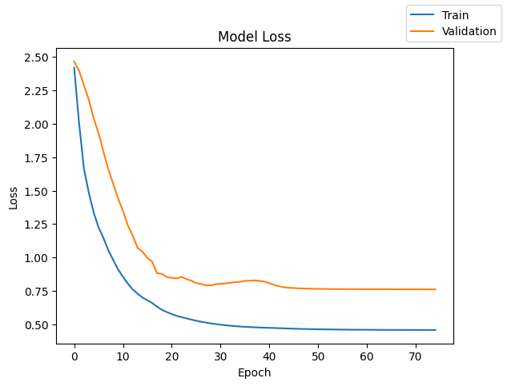

```python
plot(history, 'loss')
```

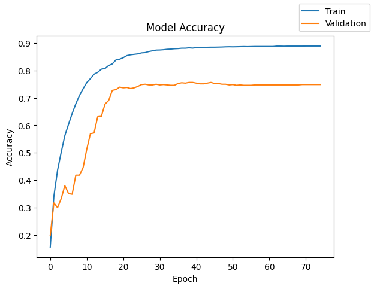

```python
plot(history, 'accuracy')
```

- The 1st model is simple with 3 convolution layers, 1 dense layer, and 1 output layer.
- The model is compiled with SGD(learning_rate=1e-3, momentum=0.9)
- The model is fitted with a batch size of 64 and applied with callbacks of early stopping and learning rate schedule.
- The accuracy of the test set is quite good, at 73% with a loss of 0.8. However, the model is expected to be overfitted.

## Model Performance Improvement

**Reducing the Learning Rate:**

**Hint**: Use **ReduceLRonPlateau()** function that will be used to decrease the learning rate by some factor, if the loss is not decreasing for some time. This may start decreasing the loss at a smaller learning rate. There is a possibility that the loss may still not decrease. This may lead to executing the learning rate reduction again in an attempt to achieve a lower loss.

### **Data Augmentation**

Remember, **data augmentation should not be used in the validation/test data set**.

**Note**: Data Augmentation in this project is implemented with references from our [Great Learning Blog](https://www.mygreatlearning.com/blog/understanding-data-augmentation/)

#### Custom Model / HyperTuning / 2nd Model

```python
reset_session()
```

```python
def create_HPmodel(hp):

    model = Sequential()

    model.add(keras.layers.Input(shape=input_shape))

    hp_dropout = hp.Choice('dropout', values=[0.3, 0.5])

    # Block 1
    model.add(Conv2D(64, (3, 3), padding='same'))
    model.add(BatchNormalization())
    model.add(Activation('relu'))
    model.add(Dropout(hp_dropout))
    model.add(Conv2D(64, (3, 3), padding='same'))
    model.add(BatchNormalization())
    model.add(Activation('relu'))
    model.add(MaxPooling2D((2, 2), strides=(2, 2)))
    model.add(Dropout(hp_dropout))

    # Block 2
    model.add(Conv2D(128, (3, 3), padding='same'))
    model.add(BatchNormalization())
    model.add(Activation('relu'))
    model.add(Dropout(hp_dropout))
    model.add(Conv2D(128, (3, 3), padding='same'))
    model.add(BatchNormalization())
    model.add(Activation('relu'))
    model.add(MaxPooling2D((2, 2), strides=(2, 2)))
    model.add(Dropout(hp_dropout))

    # Block 3
    model.add(Conv2D(256, (3, 3), padding='same'))
    model.add(BatchNormalization())
    model.add(Activation('relu'))
    model.add(Dropout(hp_dropout))
    model.add(Conv2D(256, (3, 3), padding='same'))
    model.add(BatchNormalization())
    model.add(Activation('relu'))
    model.add(Dropout(hp_dropout))
    model.add(Conv2D(256, (3, 3), padding='same'))
    model.add(BatchNormalization())
    model.add(Activation('relu'))
    model.add(MaxPooling2D((2, 2), strides=(2, 2)))
    model.add(Dropout(hp_dropout))

    # Block 4
    model.add(Conv2D(512, (3, 3), padding='same'))
    model.add(BatchNormalization())
    model.add(Activation('relu'))
    model.add(Dropout(hp_dropout))
    model.add(Conv2D(512, (3, 3), padding='same'))
    model.add(BatchNormalization())
    model.add(Activation('relu'))
    model.add(Dropout(hp_dropout))
    model.add(Conv2D(512, (3, 3), padding='same'))
    model.add(BatchNormalization())
    model.add(Activation('relu'))
    model.add(MaxPooling2D((2, 2), strides=(2, 2)))
    model.add(Dropout(hp_dropout))

    # Block 5
    model.add(Conv2D(512, (3, 3), padding='same'))
    model.add(BatchNormalization())
    model.add(Activation('relu'))
    model.add(Dropout(hp_dropout))
    model.add(Conv2D(512, (3, 3), padding='same'))
    model.add(BatchNormalization())
    model.add(Activation('relu'))
    model.add(Dropout(hp_dropout))
    model.add(Conv2D(512, (3, 3), padding='same'))
    model.add(BatchNormalization())
    model.add(Activation('relu'))
    model.add(MaxPooling2D((2, 2), strides=(2, 2)))
    model.add(Dropout(hp_dropout))

    hp_layer1 = hp.Choice('units_1', [128, 256])
    hp_layer2 = hp.Choice('units_2', [128, 256])


    # Adding a dense output layer
    model.add(Flatten())
    model.add(Dense(hp_layer1, activation='relu'))
    model.add(Dense(hp_layer2, activation='relu'))
    model.add(Dropout(hp_dropout))
    model.add(Dense(12, activation='softmax'))

    model.compile(loss='sparse_categorical_crossentropy', optimizer='adam', metrics=['accuracy'])

    return model
```

```python
tuner = RandomSearch(create_HPmodel, objective='val_accuracy', max_trials=1, executions_per_trial=1, overwrite=True, directory='dir', project_name='CV')
```

```python
tuner.search(X_train, y_train, epochs=150, batch_size=64, validation_data=(X_val, y_val), callbacks=[reduce_lr, early_stopping])
```

```
Trial 1 Complete [00h 41m 39s]
val_accuracy: 0.38026314973831177

Best val_accuracy So Far: 0.38026314973831177
Total elapsed time: 00h 41m 39s
```

```python
tuner.results_summary()
```

```
Results summary
Results in dir\CV
Showing 10 best trials
Objective(name="val_accuracy", direction="max")

Trial 0 summary
Hyperparameters:
dropout: 0.3
units_1: 128
units_2: 256
Score: 0.38026314973831177
```

```python
best_hps = tuner.get_best_hyperparameters()[0]
#best_model = tuner1.hypermodel.build(best_hps)
best_model = tuner.get_best_models()[0]
history_hp = best_model.fit(X_train, y_train, epochs=100, batch_size=64, validation_data=(X_val, y_val), \
                         shuffle=True,  verbose=1, callbacks=[reduce_lr, early_stopping])
```

```
48/48 ━━━━━━━━━━━━━━━━━━━━ 131s 3s/step - accuracy: 0.5235 - loss: 1.3527 - val_accuracy: 0.2632 - val_loss: 4.9165 - learning_rate: 0.0010
48/48 ━━━━━━━━━━━━━━━━━━━━ 131s 3s/step - accuracy: 0.5992 - loss: 1.1363 - val_accuracy: 0.1105 - val_loss: 5.5995 - learning_rate: 0.0010
48/48 ━━━━━━━━━━━━━━━━━━━━ 129s 3s/step - accuracy: 0.6425 - loss: 1.0535 - val_accuracy: 0.1066 - val_loss: 6.7841 - learning_rate: 0.0010
48/48 ━━━━━━━━━━━━━━━━━━━━ 125s 3s/step - accuracy: 0.6525 - loss: 0.9595 - val_accuracy: 0.1329 - val_loss: 5.5954 - learning_rate: 0.0010
48/48 ━━━━━━━━━━━━━━━━━━━━ 129s 3s/step - accuracy: 0.6827 - loss: 0.9182 - val_accuracy: 0.3105 - val_loss: 7.1139 - learning_rate: 0.0010
48/48 ━━━━━━━━━━━━━━━━━━━━ 128s 3s/step - accuracy: 0.7038 - loss: 0.8677 - val_accuracy: 0.3289 - val_loss: 2.9006 - learning_rate: 0.0010
48/48 ━━━━━━━━━━━━━━━━━━━━ 129s 3s/step - accuracy: 0.7124 - loss: 0.7887 - val_accuracy: 0.5303 - val_loss: 1.5143 - learning_rate: 0.0010
48/48 ━━━━━━━━━━━━━━━━━━━━ 126s 3s/step - accuracy: 0.7145 - loss: 0.7826 - val_accuracy: 0.3461 - val_loss: 3.1944 - learning_rate: 0.0010
48/48 ━━━━━━━━━━━━━━━━━━━━ 128s 3s/step - accuracy: 0.7606 - loss: 0.6758 - val_accuracy: 0.6316 - val_loss: 1.3029 - learning_rate: 0.0010
48/48 ━━━━━━━━━━━━━━━━━━━━ 132s 3s/step - accuracy: 0.7714 - loss: 0.6424 - val_accuracy: 0.6895 - val_loss: 1.2350 - learning_rate: 0.0010
48/48 ━━━━━━━━━━━━━━━━━━━━ 133s 3s/step - accuracy: 0.7801 - loss: 0.5992 - val_accuracy: 0.6263 - val_loss: 1.5148 - learning_rate: 0.0010
48/48 ━━━━━━━━━━━━━━━━━━━━ 132s 3s/step - accuracy: 0.8047 - loss: 0.5520 - val_accuracy: 0.6987 - val_loss: 0.9901 - learning_rate: 0.0010
48/48 ━━━━━━━━━━━━━━━━━━━━ 131s 3s/step - accuracy: 0.7971 - loss: 0.5530 - val_accuracy: 0.5329 - val_loss: 1.9824 - learning_rate: 0.0010
48/48 ━━━━━━━━━━━━━━━━━━━━ 134s 3s/step - accuracy: 0.8201 - loss: 0.4914 - val_accuracy: 0.6105 - val_loss: 1.6194 - learning_rate: 0.0010
48/48 ━━━━━━━━━━━━━━━━━━━━ 130s 3s/step - accuracy: 0.8426 - loss: 0.4778 - val_accuracy: 0.5237 - val_loss: 1.9484 - learning_rate: 0.0010
48/48 ━━━━━━━━━━━━━━━━━━━━ 128s 3s/step - accuracy: 0.8423 - loss: 0.4396 - val_accuracy: 0.6645 - val_loss: 1.4779 - learning_rate: 0.0010
48/48 ━━━━━━━━━━━━━━━━━━━━ 128s 3s/step - accuracy: 0.8350 - loss: 0.4542 - val_accuracy: 0.5526 - val_loss: 1.7000 - learning_rate: 0.0010
48/48 ━━━━━━━━━━━━━━━━━━━━ 131s 3s/step - accuracy: 0.8648 - loss: 0.3926 - val_accuracy: 0.5618 - val_loss: 1.6025 - learning_rate: 0.0010
48/48 ━━━━━━━━━━━━━━━━━━━━ 126s 3s/step - accuracy: 0.8517 - loss: 0.4522 - val_accuracy: 0.7434 - val_loss: 0.8700 - learning_rate: 0.0010
48/48 ━━━━━━━━━━━━━━━━━━━━ 124s 3s/step - accuracy: 0.8747 - loss: 0.3359 - val_accuracy: 0.8066 - val_loss: 0.6846 - learning_rate: 0.0010
48/48 ━━━━━━━━━━━━━━━━━━━━ 124s 3s/step - accuracy: 0.8615 - loss: 0.3839 - val_accuracy: 0.4882 - val_loss: 2.9052 - learning_rate: 0.0010
48/48 ━━━━━━━━━━━━━━━━━━━━ 124s 3s/step - accuracy: 0.8744 - loss: 0.3409 - val_accuracy: 0.5066 - val_loss: 1.9106 - learning_rate: 0.0010
48/48 ━━━━━━━━━━━━━━━━━━━━ 124s 3s/step - accuracy: 0.8770 - loss: 0.3238 - val_accuracy: 0.2750 - val_loss: 3.9425 - learning_rate: 0.0010
48/48 ━━━━━━━━━━━━━━━━━━━━ 124s 3s/step - accuracy: 0.8805 - loss: 0.3202 - val_accuracy: 0.6421 - val_loss: 1.8071 - learning_rate: 0.0010
48/48 ━━━━━━━━━━━━━━━━━━━━ 129s 3s/step - accuracy: 0.8886 - loss: 0.3229 - val_accuracy: 0.4961 - val_loss: 2.3426 - learning_rate: 0.0010
48/48 ━━━━━━━━━━━━━━━━━━━━ 129s 3s/step - accuracy: 0.9036 - loss: 0.2699 - val_accuracy: 0.6224 - val_loss: 1.5174 - learning_rate: 0.0010
48/48 ━━━━━━━━━━━━━━━━━━━━ 124s 3s/step - accuracy: 0.9059 - loss: 0.2487 - val_accuracy: 0.6434 - val_loss: 1.6476 - learning_rate: 0.0010
48/48 ━━━━━━━━━━━━━━━━━━━━ 129s 3s/step - accuracy: 0.9065 - loss: 0.2778 - val_accuracy: 0.7921 - val_loss: 0.9252 - learning_rate: 0.0010
48/48 ━━━━━━━━━━━━━━━━━━━━ 131s 3s/step - accuracy: 0.9098 - loss: 0.2500 - val_accuracy: 0.6908 - val_loss: 1.6048 - learning_rate: 0.0010
48/48 ━━━━━━━━━━━━━━━━━━━━ 130s 3s/step - accuracy: 0.9245 - loss: 0.2251 - val_accuracy: 0.5750 - val_loss: 1.8396 - learning_rate: 0.0010
48/48 ━━━━━━━━━━━━━━━━━━━━ 131s 3s/step - accuracy: 0.9108 - loss: 0.2538 - val_accuracy: 0.8026 - val_loss: 0.7231 - learning_rate: 0.0010
48/48 ━━━━━━━━━━━━━━━━━━━━ 131s 3s/step - accuracy: 0.9270 - loss: 0.2056 - val_accuracy: 0.6329 - val_loss: 2.0238 - learning_rate: 0.0010
48/48 ━━━━━━━━━━━━━━━━━━━━ 131s 3s/step - accuracy: 0.9340 - loss: 0.1908 - val_accuracy: 0.8211 - val_loss: 0.8779 - learning_rate: 0.0010
48/48 ━━━━━━━━━━━━━━━━━━━━ 129s 3s/step - accuracy: 0.9163 - loss: 0.2232 - val_accuracy: 0.7724 - val_loss: 0.9461 - learning_rate: 0.0010
48/48 ━━━━━━━━━━━━━━━━━━━━ 126s 3s/step - accuracy: 0.9407 - loss: 0.1698 - val_accuracy: 0.7303 - val_loss: 1.1820 - learning_rate: 0.0010
48/48 ━━━━━━━━━━━━━━━━━━━━ 128s 3s/step - accuracy: 0.9258 - loss: 0.2036 - val_accuracy: 0.8079 - val_loss: 0.8518 - learning_rate: 0.0010
48/48 ━━━━━━━━━━━━━━━━━━━━ 132s 3s/step - accuracy: 0.9338 - loss: 0.1985 - val_accuracy: 0.8671 - val_loss: 0.5311 - learning_rate: 0.0010
48/48 ━━━━━━━━━━━━━━━━━━━━ 128s 3s/step - accuracy: 0.9410 - loss: 0.1733 - val_accuracy: 0.7566 - val_loss: 1.0975 - learning_rate: 0.0010
```

[output cut: 19 more lines]

```python
best_hps.values
```

```
{'dropout': 0.3, 'units_1': 128, 'units_2': 256}
```

```python
# best_model.summary()
```

```python
best_model.save('Models/Best_model.keras')
```

```python
best_model.evaluate(X_test, y_test)
```

```
30/30 ━━━━━━━━━━━━━━━━━━━━ 9s 291ms/step - accuracy: 0.8552 - loss: 0.4857
```

```
[0.4899561107158661, 0.8663157820701599]
```

- The RandomSearch gives a result for dropout of 0.3, the first dense layer of 128, followed by 256 neurons.
- The accuracy of the test set is at 86%, with a loss of 0.48.

#### Data Augmentation

```python
# Some basic data augmentation techniques
datagen = ImageDataGenerator(rotation_range=20, # Random Rotation
                             shear_range=0.1, # Random Shearing
                             width_shift_range=0.1, height_shift_range=0.1, # Random Shifts
                             horizontal_flip=True, vertical_flip=False,   # Horizonal & Vertical Flips
                             zoom_range=0.1, # Random Zoom
                             fill_mode='nearest')
train_generator = datagen.flow(X_train, y_train, batch_size=64,seed=42)
```

```python
test_datagen = ImageDataGenerator()
test_generator = datagen.flow(X_test, y_test, batch_size=64,seed=42)
```

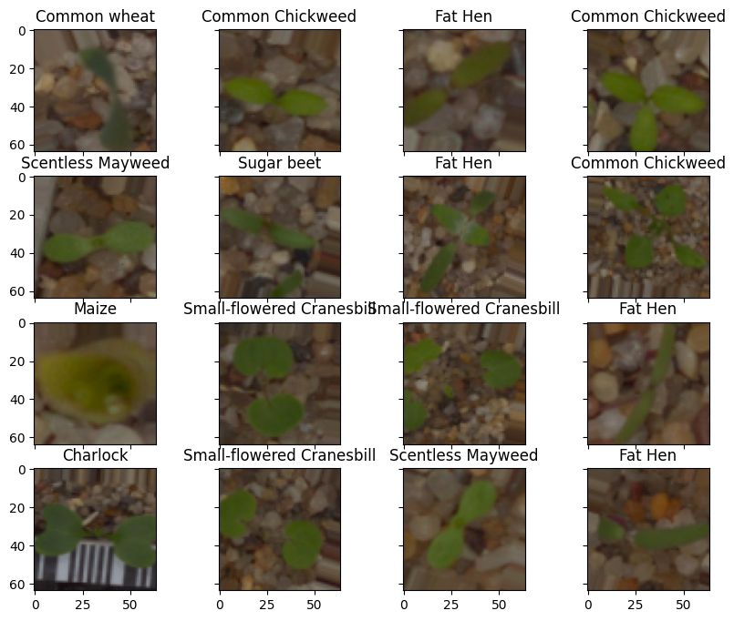

```python
rows=cols=4 # Defining number of rows=4
classes = cat_labels
fig, ax = plt.subplots(rows, cols, sharex=True, sharey=True, figsize=(10,8))
for i in range(rows):
    for j in range(cols):
        for X_batch, y_batch in train_generator:
            ax[i][j].imshow(X_batch[0], cmap=plt.get_cmap('gray'));
            #ax[i][j].set_title(y_batch[0].dot(classes))
            ax[i][j].set_title(classes[y_batch[0]])
            break
plt.show;
```

```python
testX, testY = next(test_generator)
```

```python
history_gen = best_model.fit(train_generator,steps_per_epoch=(len(X_train))//64, epochs=100,
                              validation_data=(testX, testY), callbacks=[reduce_lr, early_stopping], verbose=1)
```

```
47/47 ━━━━━━━━━━━━━━━━━━━━ 117s 2s/step - accuracy: 0.8217 - loss: 0.4716 - val_accuracy: 0.4531 - val_loss: 2.0194 - learning_rate: 0.0010
47/47 ━━━━━━━━━━━━━━━━━━━━ 2s 14ms/step - accuracy: 0.8750 - loss: 0.3725 - val_accuracy: 0.4219 - val_loss: 2.1504 - learning_rate: 0.0010
47/47 ━━━━━━━━━━━━━━━━━━━━ 120s 3s/step - accuracy: 0.8774 - loss: 0.3747 - val_accuracy: 0.7031 - val_loss: 0.8873 - learning_rate: 0.0010
47/47 ━━━━━━━━━━━━━━━━━━━━ 3s 13ms/step - accuracy: 0.7812 - loss: 0.6144 - val_accuracy: 0.7188 - val_loss: 0.8735 - learning_rate: 0.0010
47/47 ━━━━━━━━━━━━━━━━━━━━ 117s 2s/step - accuracy: 0.8559 - loss: 0.4362 - val_accuracy: 0.6719 - val_loss: 1.0413 - learning_rate: 0.0010
47/47 ━━━━━━━━━━━━━━━━━━━━ 3s 13ms/step - accuracy: 0.8281 - loss: 0.6717 - val_accuracy: 0.7344 - val_loss: 0.9703 - learning_rate: 0.0010
47/47 ━━━━━━━━━━━━━━━━━━━━ 116s 2s/step - accuracy: 0.8499 - loss: 0.4205 - val_accuracy: 0.5625 - val_loss: 1.4293 - learning_rate: 0.0010
47/47 ━━━━━━━━━━━━━━━━━━━━ 3s 13ms/step - accuracy: 0.8281 - loss: 0.5707 - val_accuracy: 0.5469 - val_loss: 1.4402 - learning_rate: 0.0010
47/47 ━━━━━━━━━━━━━━━━━━━━ 116s 2s/step - accuracy: 0.8466 - loss: 0.3946 - val_accuracy: 0.6094 - val_loss: 1.5558 - learning_rate: 0.0010
47/47 ━━━━━━━━━━━━━━━━━━━━ 3s 13ms/step - accuracy: 0.8125 - loss: 0.5159 - val_accuracy: 0.6094 - val_loss: 1.5114 - learning_rate: 0.0010
47/47 ━━━━━━━━━━━━━━━━━━━━ 116s 2s/step - accuracy: 0.8683 - loss: 0.3660 - val_accuracy: 0.3906 - val_loss: 2.9466 - learning_rate: 0.0010
47/47 ━━━━━━━━━━━━━━━━━━━━ 3s 13ms/step - accuracy: 0.9062 - loss: 0.2987 - val_accuracy: 0.3594 - val_loss: 2.8510 - learning_rate: 0.0010
47/47 ━━━━━━━━━━━━━━━━━━━━ 116s 2s/step - accuracy: 0.8795 - loss: 0.3412 - val_accuracy: 0.5469 - val_loss: 1.1716 - learning_rate: 0.0010
47/47 ━━━━━━━━━━━━━━━━━━━━ 3s 15ms/step - accuracy: 0.8906 - loss: 0.2378 - val_accuracy: 0.6562 - val_loss: 1.0643 - learning_rate: 0.0010
47/47 ━━━━━━━━━━━━━━━━━━━━ 117s 2s/step - accuracy: 0.8687 - loss: 0.3647 - val_accuracy: 0.6719 - val_loss: 0.9462 - learning_rate: 0.0010
47/47 ━━━━━━━━━━━━━━━━━━━━ 3s 13ms/step - accuracy: 0.9375 - loss: 0.2478 - val_accuracy: 0.6562 - val_loss: 0.9656 - learning_rate: 0.0010
47/47 ━━━━━━━━━━━━━━━━━━━━ 116s 2s/step - accuracy: 0.8833 - loss: 0.3388 - val_accuracy: 0.6562 - val_loss: 0.7352 - learning_rate: 0.0010
47/47 ━━━━━━━━━━━━━━━━━━━━ 3s 13ms/step - accuracy: 0.9062 - loss: 0.1706 - val_accuracy: 0.6406 - val_loss: 0.7398 - learning_rate: 0.0010
47/47 ━━━━━━━━━━━━━━━━━━━━ 116s 2s/step - accuracy: 0.8773 - loss: 0.3697 - val_accuracy: 0.7812 - val_loss: 0.5639 - learning_rate: 0.0010
47/47 ━━━━━━━━━━━━━━━━━━━━ 3s 14ms/step - accuracy: 0.9062 - loss: 0.2131 - val_accuracy: 0.7969 - val_loss: 0.5045 - learning_rate: 0.0010
47/47 ━━━━━━━━━━━━━━━━━━━━ 115s 2s/step - accuracy: 0.8939 - loss: 0.3160 - val_accuracy: 0.6094 - val_loss: 1.6644 - learning_rate: 0.0010
47/47 ━━━━━━━━━━━━━━━━━━━━ 3s 13ms/step - accuracy: 0.9219 - loss: 0.2579 - val_accuracy: 0.5938 - val_loss: 1.8750 - learning_rate: 0.0010
47/47 ━━━━━━━━━━━━━━━━━━━━ 115s 2s/step - accuracy: 0.8859 - loss: 0.3489 - val_accuracy: 0.8125 - val_loss: 0.7250 - learning_rate: 0.0010
47/47 ━━━━━━━━━━━━━━━━━━━━ 3s 13ms/step - accuracy: 0.9688 - loss: 0.1737 - val_accuracy: 0.8125 - val_loss: 0.6748 - learning_rate: 0.0010
47/47 ━━━━━━━━━━━━━━━━━━━━ 114s 2s/step - accuracy: 0.9027 - loss: 0.3078 - val_accuracy: 0.6875 - val_loss: 0.9336 - learning_rate: 0.0010
47/47 ━━━━━━━━━━━━━━━━━━━━ 3s 13ms/step - accuracy: 0.8594 - loss: 0.3131 - val_accuracy: 0.7031 - val_loss: 0.9247 - learning_rate: 0.0010
47/47 ━━━━━━━━━━━━━━━━━━━━ 115s 2s/step - accuracy: 0.9065 - loss: 0.2853 - val_accuracy: 0.5781 - val_loss: 2.1043 - learning_rate: 0.0010
47/47 ━━━━━━━━━━━━━━━━━━━━ 3s 13ms/step - accuracy: 0.8594 - loss: 0.3640 - val_accuracy: 0.4531 - val_loss: 3.2036 - learning_rate: 0.0010
47/47 ━━━━━━━━━━━━━━━━━━━━ 115s 2s/step - accuracy: 0.8954 - loss: 0.3076 - val_accuracy: 0.6875 - val_loss: 1.4027 - learning_rate: 0.0010
47/47 ━━━━━━━━━━━━━━━━━━━━ 3s 14ms/step - accuracy: 0.8281 - loss: 0.5343 - val_accuracy: 0.5312 - val_loss: 2.0500 - learning_rate: 0.0010
47/47 ━━━━━━━━━━━━━━━━━━━━ 115s 2s/step - accuracy: 0.8975 - loss: 0.2920 - val_accuracy: 0.7969 - val_loss: 0.7251 - learning_rate: 0.0010
47/47 ━━━━━━━━━━━━━━━━━━━━ 3s 13ms/step - accuracy: 0.9375 - loss: 0.2047 - val_accuracy: 0.7188 - val_loss: 0.8696 - learning_rate: 0.0010
47/47 ━━━━━━━━━━━━━━━━━━━━ 115s 2s/step - accuracy: 0.8990 - loss: 0.3020 - val_accuracy: 0.7344 - val_loss: 0.9455 - learning_rate: 0.0010
47/47 ━━━━━━━━━━━━━━━━━━━━ 3s 13ms/step - accuracy: 0.8906 - loss: 0.3118 - val_accuracy: 0.6562 - val_loss: 1.0202 - learning_rate: 0.0010
47/47 ━━━━━━━━━━━━━━━━━━━━ 115s 2s/step - accuracy: 0.9045 - loss: 0.2688 - val_accuracy: 0.6406 - val_loss: 1.3016 - learning_rate: 0.0010
47/47 ━━━━━━━━━━━━━━━━━━━━ 3s 13ms/step - accuracy: 0.9688 - loss: 0.1036 - val_accuracy: 0.6719 - val_loss: 1.3123 - learning_rate: 0.0010
47/47 ━━━━━━━━━━━━━━━━━━━━ 115s 2s/step - accuracy: 0.9003 - loss: 0.2887 - val_accuracy: 0.6562 - val_loss: 1.2841 - learning_rate: 0.0010
47/47 ━━━━━━━━━━━━━━━━━━━━ 3s 13ms/step - accuracy: 0.8281 - loss: 0.3303 - val_accuracy: 0.6250 - val_loss: 1.3173 - learning_rate: 0.0010
47/47 ━━━━━━━━━━━━━━━━━━━━ 115s 2s/step - accuracy: 0.9012 - loss: 0.2964 - val_accuracy: 0.7188 - val_loss: 1.0041 - learning_rate: 0.0010
47/47 ━━━━━━━━━━━━━━━━━━━━ 3s 13ms/step - accuracy: 0.9375 - loss: 0.2309 - val_accuracy: 0.6719 - val_loss: 1.0296 - learning_rate: 0.0010
```

```python
best_model.evaluate(test_generator)
```

```
15/15 ━━━━━━━━━━━━━━━━━━━━ 8s 545ms/step - accuracy: 0.8588 - loss: 0.4146
```

```
[0.4380588233470917, 0.8568421006202698]
```

```python
best_model.save('Models/augmentation_model.keras')
```

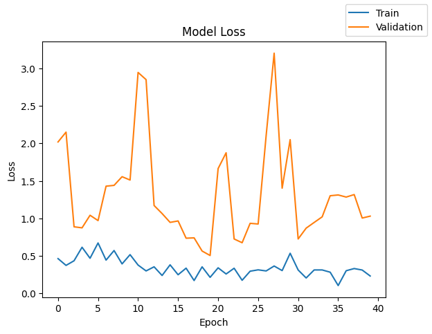

```python
plot(history_gen, 'loss')
```

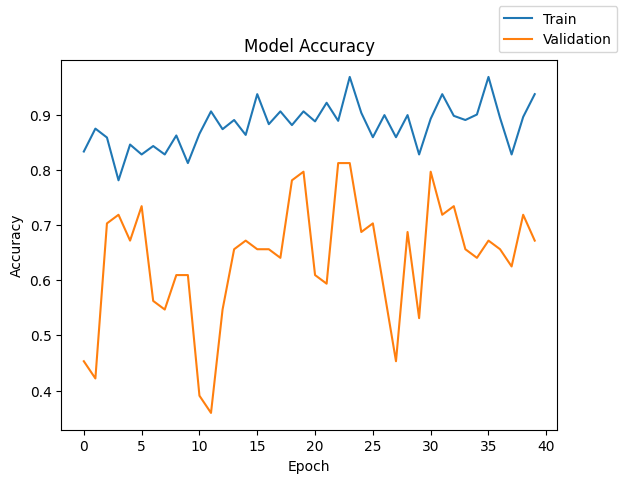

```python
plot(history_gen, 'accuracy')
```

#### Transfer Learning VGG16 (3rd Model)

```python
base_model = VGG16(weights='imagenet', include_top = False, input_shape = input_shape)
base_model.trainable = False
```

```python
def create_VGG_model():
    model = Sequential()
    # Adding the convolutional part of the VGG16 model
    model.add(base_model)
    # Flattening the output of the VGG16 model
    model.add(Flatten())
    # Adding a dense output layer
    model.add(Dense(128))
    model.add(BatchNormalization())
    model.add(Activation('relu'))
    model.add(Dropout(0.3))
    model.add(Dense(256))
    model.add(BatchNormalization())
    model.add(Activation('relu'))
    model.add(Dropout(0.3))
    model.add(Dense(12, activation='softmax'))

    return model
```

```python
VGG_model = create_VGG_model()
VGG_model.summary()
```

```
Model: "sequential_1"
```

```
┏━━━━━━━━━━━━━━━━━━━━━━━━━━━━━━━━━┳━━━━━━━━━━━━━━━━━━━━━━━━┳━━━━━━━━━━━━━━━┓
┃ Layer (type)                    ┃ Output Shape           ┃       Param # ┃
┡━━━━━━━━━━━━━━━━━━━━━━━━━━━━━━━━━╇━━━━━━━━━━━━━━━━━━━━━━━━╇━━━━━━━━━━━━━━━┩
│ vgg16 (Functional)              │ (None, 2, 2, 512)      │    14,714,688 │
├─────────────────────────────────┼────────────────────────┼───────────────┤
│ flatten_1 (Flatten)             │ (None, 2048)           │             0 │
├─────────────────────────────────┼────────────────────────┼───────────────┤
│ dense_3 (Dense)                 │ (None, 128)            │       262,272 │
├─────────────────────────────────┼────────────────────────┼───────────────┤
│ batch_normalization_13          │ (None, 128)            │           512 │
│ (BatchNormalization)            │                        │               │
├─────────────────────────────────┼────────────────────────┼───────────────┤
│ activation_13 (Activation)      │ (None, 128)            │             0 │
├─────────────────────────────────┼────────────────────────┼───────────────┤
│ dropout_14 (Dropout)            │ (None, 128)            │             0 │
├─────────────────────────────────┼────────────────────────┼───────────────┤
│ dense_4 (Dense)                 │ (None, 256)            │        33,024 │
├─────────────────────────────────┼────────────────────────┼───────────────┤
│ batch_normalization_14          │ (None, 256)            │         1,024 │
│ (BatchNormalization)            │                        │               │
├─────────────────────────────────┼────────────────────────┼───────────────┤
│ activation_14 (Activation)      │ (None, 256)            │             0 │
├─────────────────────────────────┼────────────────────────┼───────────────┤
│ dropout_15 (Dropout)            │ (None, 256)            │             0 │
├─────────────────────────────────┼────────────────────────┼───────────────┤
│ dense_5 (Dense)                 │ (None, 12)             │         3,084 │
└─────────────────────────────────┴────────────────────────┴───────────────┘
```

```
 Total params: 15,014,604 (57.28 MB)
```

```
 Trainable params: 299,148 (1.14 MB)
```

```
 Non-trainable params: 14,715,456 (56.14 MB)
```

```python
VGG_model.compile(optimizer=Adam(learning_rate=0.001), loss='sparse_categorical_crossentropy', metrics=['accuracy'])
```

```python
early_stopping = EarlyStopping(monitor='val_loss', patience=20, restore_best_weights=True, start_from_epoch=48)
```

```python
# Fitting the VGG model
VGG_history = VGG_model.fit(train_generator,
                                  validation_data=(testX, testY),
                                  epochs=1, callbacks=[early_stopping, reduce_lr])
```

```
48/48 ━━━━━━━━━━━━━━━━━━━━ 66s 1s/step - accuracy: 0.6865 - loss: 0.9077 - val_accuracy: 0.5469 - val_loss: 1.2604 - learning_rate: 1.3604e-06
```

```python
# Evaluating on the Test set
VGG_model.evaluate(test_generator)
```

```
15/15 ━━━━━━━━━━━━━━━━━━━━ 7s 456ms/step - accuracy: 0.6384 - loss: 1.0265
```

```
[1.0457329750061035, 0.6315789222717285]
```

#### VGG16 Transfer Learning Model Fine-tuning with image dataset from directory

```python
batch_size = 64
img_height = 64
img_width = 64

train_ds = tf.keras.utils.image_dataset_from_directory(
      "archive",
      validation_split=0.2,
      subset='training',
      seed=42,
      image_size=(img_height, img_width),
      batch_size=batch_size)

val_ds = tf.keras.utils.image_dataset_from_directory(
      "archive",
      validation_split=0.2,
      subset='validation',
      seed=42,
      image_size=(img_height, img_width),
      batch_size=batch_size)

class_names = train_ds.class_names
```

```
Found 5539 files belonging to 12 classes.
Using 4432 files for training.
Found 5539 files belonging to 12 classes.
Using 1107 files for validation.
```

```python
val_size = int(0.5* val_ds.cardinality().numpy())
val_set = val_ds.take(val_size)
test_set = val_ds.skip(val_size)

print(val_ds.cardinality().numpy())
print(val_set.cardinality().numpy())
print(test_set.cardinality().numpy())
```

```
18
9
9
```

```python
class_names
```

```
['Black grass',
 'Charlock',
 'Cleavers',
 'Common Chickweed',
 'Common wheat',
 'Fat Hen',
 'Loose Silky bent',
 'Maize',
 'Scentless Mayweed',
 'Shepherds Purse',
 'Small flowered Cranesbill',
 'Sugar beet']
```

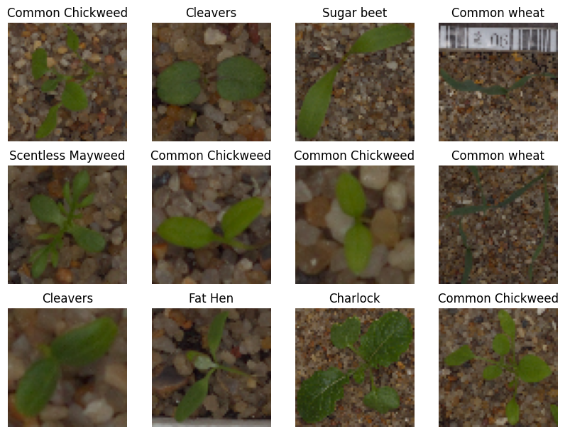

```python
plt.figure(figsize=(10, 10))
for images, labels in train_ds.take(1):
  for i in range(12):
    ax = plt.subplot(4, 4, i + 1)
    plt.imshow(images[i].numpy().astype("uint8"))
    plt.title(class_names[labels[i]])
    plt.axis("off")
```

```python
normalization_layer = tf.keras.layers.Rescaling(1./255)

normalized_train_ds = train_ds.map(lambda x, y: (normalization_layer(x), y))
normalized_val_ds = val_set.map(lambda x, y: (normalization_layer(x), y))
normalized_test_ds= test_set.map(lambda x, y: (normalization_layer(x), y))
```

```python
AUTOTUNE = tf.data.AUTOTUNE
normalized_train_ds = normalized_train_ds.cache().prefetch(buffer_size=AUTOTUNE)
normalized_val_ds = normalized_val_ds.cache().prefetch(buffer_size=AUTOTUNE)
normalized_test_ds = normalized_test_ds.cache().prefetch(buffer_size=AUTOTUNE)
```

```python
early_stopping = EarlyStopping(monitor='val_loss', patience=20, restore_best_weights=True, start_from_epoch=20)
```

```python
base_model.trainable = True
```

```python
VGG_model.compile(optimizer=Adam(learning_rate=1e-5), loss='sparse_categorical_crossentropy', metrics=['accuracy'])
```

```python
VGG_model.fit(normalized_train_ds, validation_data=normalized_val_ds, epochs=1,  callbacks=[early_stopping, lr_scheduler])
```

```
70/70 ━━━━━━━━━━━━━━━━━━━━ 108s 2s/step - accuracy: 0.9931 - loss: 0.0930 - val_accuracy: 0.8767 - val_loss: 0.3348 - learning_rate: 1.2277e-07
```

```
<keras.src.callbacks.history.History at 0x17d42be6690>
```

```python
VGG_model.save('Models/VGG_model.keras')
```

```python
VGG_model.evaluate(normalized_test_ds)
```

```
9/9 ━━━━━━━━━━━━━━━━━━━━ 7s 442ms/step - accuracy: 0.8652 - loss: 0.3486
```

```
[0.32711151242256165, 0.8757061958312988]
```

```python
# make predictions
prediction = np.array([])
target =  np.array([])
for x, y in normalized_test_ds:
  prediction = np.concatenate([prediction, np.argmax(VGG_model.predict(x), axis = -1)])
  target = np.concatenate([target, y])
```

```
2/2 ━━━━━━━━━━━━━━━━━━━━ 1s 314ms/step
2/2 ━━━━━━━━━━━━━━━━━━━━ 1s 349ms/step
2/2 ━━━━━━━━━━━━━━━━━━━━ 1s 237ms/step
2/2 ━━━━━━━━━━━━━━━━━━━━ 0s 244ms/step
2/2 ━━━━━━━━━━━━━━━━━━━━ 0s 241ms/step
2/2 ━━━━━━━━━━━━━━━━━━━━ 0s 239ms/step
2/2 ━━━━━━━━━━━━━━━━━━━━ 0s 240ms/step
2/2 ━━━━━━━━━━━━━━━━━━━━ 0s 239ms/step
1/1 ━━━━━━━━━━━━━━━━━━━━ 0s 175ms/step
```

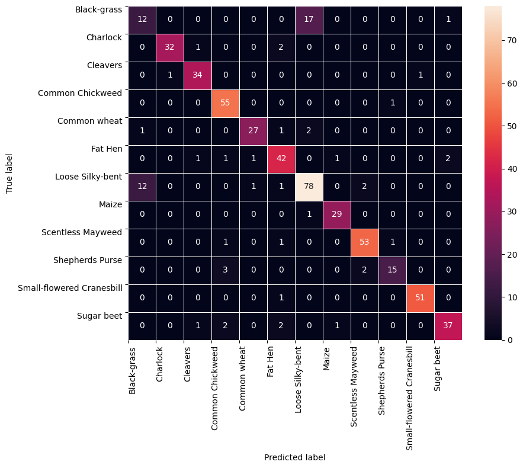

```python
# plot confusion matrix
confusion_matrix_tf(prediction, target)
```

## Final Model

Comment on the final model you have selected and use the same in the below code to visualize the image.

```python
final_model = VGG_model
```

### Visualizing the prediction

```python
# Make Predictions
model_predict = final_model
```

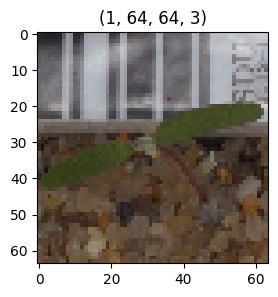

```python
# 1st test image from import dataset
img = cv2.imread('images/77FatHen.png')
img = cv2.cvtColor(img, cv2.COLOR_BGR2RGB)
img = cv2.resize(img, (64, 64), interpolation=cv2.INTER_LINEAR)
img = np.expand_dims(img, axis=0)
img = img.astype('float32')/(255)

fig = plt.figure(figsize=(3, 3))
plt.imshow(img[0], cmap=plt.get_cmap('gray'));
plt.title(img.shape);
```

```python
# Correct Prediction
prediction = model_predict.predict(img)
cat_labels[prediction.argmax() ]
```

```
1/1 ━━━━━━━━━━━━━━━━━━━━ 0s 51ms/step
```

```
'Fat Hen'
```

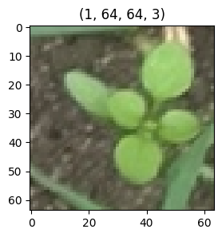

```python
# 2nd test image from ImagesFromTheWild dataset
img2 = cv2.imread('images/cleavers.tiff')
img2 = cv2.cvtColor(img2, cv2.COLOR_BGR2RGB)
img2 = cv2.resize(img2, (64, 64), interpolation=cv2.INTER_LINEAR)
img2 = np.expand_dims(img2, axis=0)
img2 = img2.astype('float32')/(255)

fig = plt.figure(figsize=(3, 3))
plt.imshow(img2[0], cmap=plt.get_cmap('gray'));
plt.title(img2.shape);
```

```python
# Wrong Prediction
prediction2 = model_predict.predict(img2)
cat_labels[prediction2.argmax() ]
```

```
1/1 ━━━━━━━━━━━━━━━━━━━━ 0s 57ms/step
```

```
'Shepherds Purse'
```

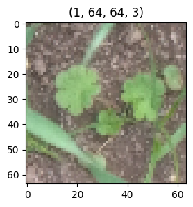

```python
# 3rd test image from ImagesFromTheWild dataset
img3 = cv2.imread('images/Small-flowered Cranesbill.tiff')
img3 = cv2.cvtColor(img3, cv2.COLOR_BGR2RGB)
img3 = cv2.resize(img3, (64, 64), interpolation=cv2.INTER_LINEAR)
img3 = np.expand_dims(img3, axis=0)
img3 = img3.astype('float32')/(255)

fig = plt.figure(figsize=(3, 3))
plt.imshow(img3[0], cmap=plt.get_cmap('gray'));
plt.title(img3.shape);
```

```python
# Correct Prediction
prediction3 = model_predict.predict(img3)
cat_labels[prediction3.argmax() ]
```

```
1/1 ━━━━━━━━━━━━━━━━━━━━ 0s 54ms/step
```

```
'Small-flowered Cranesbill'
```

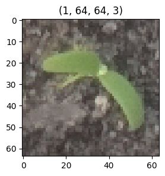

```python
# 4th test image from ImagesFromTheWild dataset
img4 = cv2.imread('images/Fat Hen.tiff')
img4 = cv2.cvtColor(img4, cv2.COLOR_BGR2RGB)
img4 = cv2.resize(img4, (64, 64), interpolation=cv2.INTER_LINEAR)
img4 = np.expand_dims(img4, axis=0)
img4 = img4.astype('float32')/(255)

fig = plt.figure(figsize=(3, 3))
plt.imshow(img4[0], cmap=plt.get_cmap('gray'));
plt.title(img4.shape);
```

```python
# Correct Prediction
prediction4 = model_predict.predict(img4)
cat_labels[prediction4.argmax() ]
```

```
1/1 ━━━━━━━━━━━━━━━━━━━━ 0s 53ms/step
```

```
'Fat Hen'
```

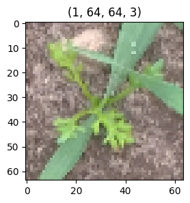

```python
# 5th test image from ImagesFromTheWild dataset
img5 = cv2.imread('images/Scentless Mayweed.tiff')
img5 = cv2.cvtColor(img5, cv2.COLOR_BGR2RGB)
img5 = cv2.resize(img5, (64, 64), interpolation=cv2.INTER_LINEAR)
img5 = np.expand_dims(img5, axis=0)
img5 = img5.astype('float32')/(255)

fig = plt.figure(figsize=(3, 3))
plt.imshow(img5[0], cmap=plt.get_cmap('gray'));
plt.title(img5.shape);
```

```python
# Correct Prediction
prediction5 = model_predict.predict(img5)
cat_labels[prediction5.argmax() ]
```

```
1/1 ━━━━━━━━━━━━━━━━━━━━ 0s 52ms/step
```

```
'Scentless Mayweed'
```

- Our model correctly identifies the plant seedling Fat Hen. However, the model fails to classify the Cleavers plant from a wild image as Shepherds Purse.
- Maybe more image processing should be done on the background or contrast to improve the predictions.

### Summary:

- All required libraries are imported in addition to the OpenCV library for image processing.
- I train and evaluate 3 models, a simple CNN model, a custom VGG model, and a VGG16 transfer learning model

The first model has 73% accuracy. The second model has 85% accuracy with hypertuning and data augmentation. The third model VGG16 Transfer Learning Model has the highest accuracy of 87%.

- In conclusion, Transfer Learning helps with training and computing resources. Once the model is retrained end to end with new weights, BatchNormalization, and Dropout, we can achieve a higher accuracy score.

## Actionable Insights and Business Recommendations

*Our fine-tuning VGG16 transfer learning model can help the Agriculture field correctly classify the 12-species plant seedlings by their young bird-eye view images. With the improvement of our AI model, the need for manual labor will be reduced and the innovation of Research will be expanded greatly. Therefore, the more wild dataset we can obtain, the better we can train our model with.

# Introduction to Computer Vision: Plant Seedlings Classification